# Donor Profile: Sweden, through Swedish International Development Cooperation Agency (Sida)

## Transaction Volatility

Sweden’s funding for humanitarian operations, averaging $1.4M per transaction across 25 transactions yearly, significantly trails top donors whose average exceeds $2.9M with nearly 587 transactions annually. This funding volatility constrains scalability and rapid response capacity, directly impacting program reach and effectiveness. Notably, lower transaction frequency limits UNHCR’s ability to leverage multi-project synergies and optimize impact multipliers. Investing to increase both transaction volume and value through enhanced partnership models is a strategic priority, unlocking a 48% expansion potential in operational scale. We recommend targeted engagement with Sida to diversify and stabilize disbursement patterns, emphasizing innovative funding instruments that align with their development priorities. Immediate action to mitigate these risks by bolstering transaction frequency will amplify Sweden’s donor impact on resilience and emergency response. Decision-makers should prioritize resource allocation to bridge these gaps, positioning Sweden as a more agile and reliable funding partner.

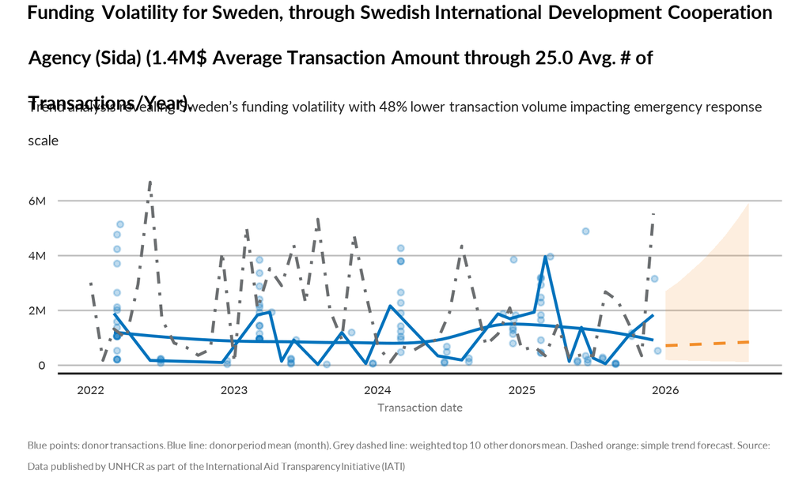